# Tree-based methods

Published

20 Mar 2023

## Tree-based methods

- trees are a basic building block of modelign methods ($\sim$ linear regression)
- **greedy** partitioning of parameter space
- efficient updating rules instead of linear algebra
- better at categorical predictors, interactions, missing data
- bias-variance tradeoff, curse of dimensionality, need for hyperparameter tuning … **still apply**

## Classification and regression trees

- recursive *binary* splitting
- builds basis of rectangular regions
  - predictions homogeneous within regions
  - could be expressed as indicator variables

## CART: machinery

- splitting rule
  - regression: improve SSQ, deviance, …
  - improve misclassification error, Gini coefficient, deviance
  - Gini coefficient: $\sum_k \hat p_{mk} (1-\hat p_{mk})$ (weighted average ($1-p$) loss)
  - deviance: $\sum \hat p_{mk} (-\log \hat p_{mk})$ (weighted average $-\log$ loss)

## tree-splitting rule complexity

- only ${\cal O}(Np)$!
- (more specifically $\sum (\# \textrm{unique}~x_i)$)
- splits only happen at data point values

## complexity pruning

- $1/N_m \sum_{x \in R_m} (y_i - \bar y_m)^2 + \alpha |T|$
- boils down to (total loss) + $\alpha$ size
- weakest-link pruning (greedy again): collapse least-useful splits first

## categorical predictors

- to avoid combinatorial splitting problems, order categories by
  - frequency falling in outcome 1 (binary output)
  - mean response value
  - optimal split for Gini/deviance/cross-entropy/L2 loss
  - multicategory harder
- favors categorical vars with many categories (“such variables should be avoided” … ???)

## loss matrix

- allow weighting of misclassification
- e.g. cost of false positive/negative, **or** value of sensitivity/specificity

## missing predictor variables

- ‘missing’ category
- use **surrogate variables** (algorithm?? effects of other splitting variables are already computed?)
- is imputation better?

## linear combination splits

- can do generalized discriminant analysis at each split
- weights, split point for $\sum a_j X_j \le s$
- seems better (Loh and Vanichsetakul 1988) but Breiman and Friedman disagree (Breiman and Friedman 1988)
- highly empirical!

Loh, Wei-Yin, and Nunta Vanichsetakul. 1988. “Tree-Structured Classification via Generalized Discriminant Analysis.” *Journal of the American Statistical Association* 83 (403): 715–25. https://doi.org/10.1080/01621459.1988.10478652.

Breiman, Leo, and Jerome H. Friedman. 1988. “Tree-Structured Classification Via Generalized Discriminant Analysis: Comment.” *Journal of the American Statistical Association* 83 (403): 725–27. https://doi.org/10.2307/2289296.

## spam example

- 4600 messages, 57 predictors (48 word percentages; punctuation percentages; sequences of capitals)
- earlier: misclassification 7.6% from logistic regression, 5.5% from GAM
- CART: 9.3%
- weighted tree does slightly better at high specificity, but still $\ll$ GAM …

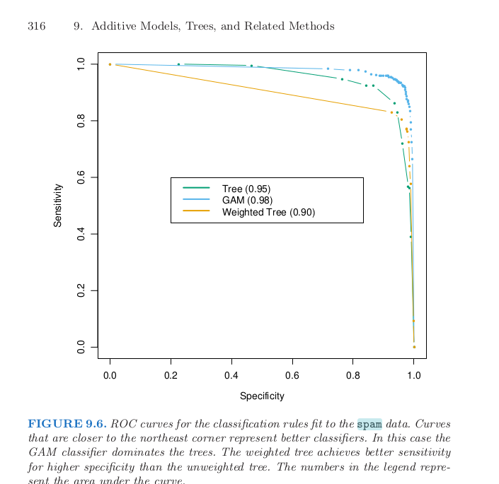

## MARS

- like decision trees but piecewise linear (+ interactions) rather than constant
- **hinges** (or “reflected pairs”): ‘mini-bases’ (pairs of truncated linear spline terms) (total $2 Np$)
- stepwise/stagewise fitting
- also include possible *interactions*
  - products of model terms with unused basis elements
  - at each step $k$ we have $2Np \cdot (2k-1)$ choices to evaluate
  - each can be evaluated in ${\cal O}(1)$
  - principle of **marginality**: only add higher-order terms if lower-order term is already present
- reasonably local basis functions (not as good as B-splines)
- hyperparameters: max interaction depth
- then prune greedily using GCV (denominator: $(1-M/N)^2$, $M = r + cK$ where $r$=number of bases, $K$ = number of knots

## MARS on spam example

- still slightly worse than GAM …
- GCV chooses model with 60 basis functions

## MARS vs CART

- stepwise vs piecewise linear basis
- presence of higher-order interactions

## MARS with categorical predictors

- “all possible binary partitions” - really?
- (use ordering trick from CART?)

## computational costs

- additive models via backfitting: $p N \log N$ (initial sort) $+ mpN$ (backfitting)
  - cf. $N p^2$ [for least-squares](https://math.stackexchange.com/questions/84495/computational-complexity-of-least-square-regression-operation)
- trees: $p N \log N$ to sort, $p N \log N$ for splits ($\log N$ cycles)
- MARS: $N m^2 + p m N$ to add a basis function to a model with $m$ terms $\to$ $N M^3 + p M^2 N$ (monitor stopping?)

## missing data (with MARS/CART)

- **danger will robinson**
- MCAR, MAR, MNAR …
- categorical: code as “missing”
- discard incomplete observations
- impute beforehand
- impute/handle as part of learning algorithm
  - impute based on mean/median
  - impute conditional on other observations (MICE)
  - trees: **surrogate splits** (easy to look for next-best split)

## random forests

- bootstrap sample data
- grow a tree with a subset of $m$ variables **at each split**
- average prediction from ensemble (mean prediction, or majority vote)
- variance of average of correlated variables = $\sigma^2 (\rho + (1-\rho)/B)$
  - $\rho \approx 0.05$ for bootstrapped **trees**
- subsetting variables reduces correlations between trees

## tuning parameters

- suggested $m = \sqrt{p}$ for classification, min node size 1 (stopping point)
  - $p/3$, min node size 5 for regression
- min node size/max depth: “our experience is that using full-grown trees seldom costs much, and results in one less tuning parameter”
- number of trees just needs to be “large enough” (curve flattens quickly)
  - monitor progression for iterative algorithms?
- super-easy to parallelize
- explore tuning parameters: https://github.com/tidymodels/TMwR/issues/356
- out-of-bag samples

## comparisons

- with many trees ($B \to \infty$), RF estimation variance shrinks to $\rho(x) \sigma^2(x)$
- correlation increases with $m$

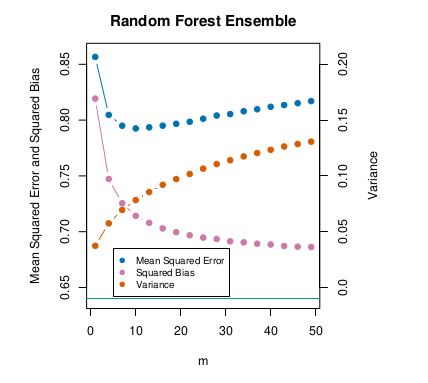

- RF similar to ridge: shrinks strongly correlated variables toward each other

## loss functions

- robustness
- how to pick???

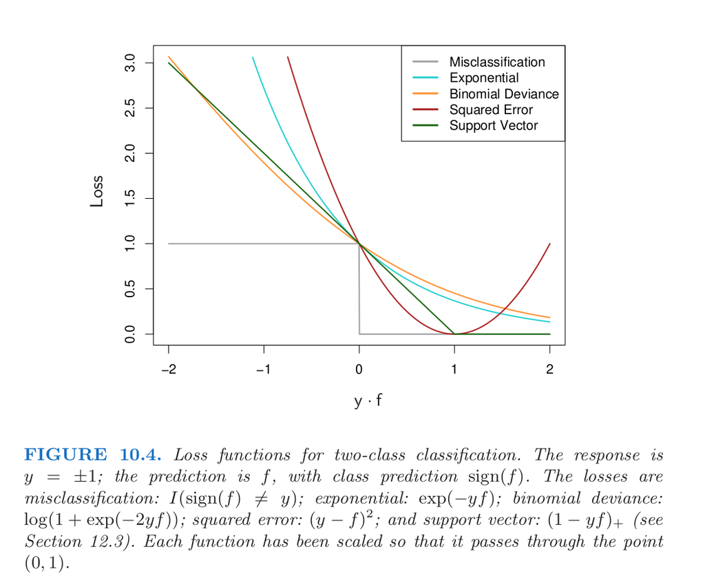

## boosting

- “deep” methods
- still an additive model
- **stagewise** rather than simultaneous
- stagewise $\approx$ stepwise, but not recomputing previous coefficients/models

## boosting: AdaBoost

- using {-1, 1} scores
- fit a classifier with current weights $w_i$
- compute **average error** (== avg weights of correct predictions)
- $\alpha_m$ = log-odds of average correctness
- weights of *incorrectly predicted* samples multiplied by odds of avg correctness
- prediction is $\textrm{sign}(\sum \alpha_m G_m(x))$
- can use probability mapped to [-1, 1] instead of classification
- corresponds to **exponential loss** $\exp(-y f)$; deviance is $\log(1+\exp(-2yf))$

## boosting (generally)

- algorithm (stagewise):
  - fit a ‘weak learner’ to *pseudo-residuals*
  - update model based on the *sum* of the previous model plus the current weak learner
- pseudo-residuals: $-\partial L/\partial \hat y$
  - = $2 (y - \hat y)$ for MSE
  - related to *generalized scoring* for GLMs etc.
  - == **gradient** of loss function
- weakest tree: “stump” (== “fork” ?)
- robust criteria don’t give rise to fast algorithms

## gradient boosting

- works for any differentiable loss function
- find gradient, line search

## gradient tree boosting algorithm

(ESL, Bujokas (2022))

Bujokas, Eligijus. 2022. “Gradient Boosting in Python from Scratch.” *Medium*. https://towardsdatascience.com/gradient-boosting-in-python-from-scratch-788d1cf1ca7.

- fit a decision tree (learner) to pseudo-residuals (= modeling the *gradient of the loss*)
- find the step size $\gamma$ to apply to the new learner:

$$\newcommand{\argmin}{\mathop{\mathrm{argmin}}}
\begin{split}
F_m(x) & = F_{m-1}(x) + \gamma_m h_m(x) \\
\gamma_m & = \argmin_{\gamma} \sum L(y_i,F_{m-1}(x) + \gamma h_m(x))
\end{split}$$
where $h_m(x)$ is the new prediction for $x$

- for MSE $\gamma_m = \frac{1/N} \sum (h_m(x) (\hat y - y))/\sum (h_m^2)$
- for regression trees, $h_m$ is **constant** in each region
- Friedman ‘TreeBoost’ optimizes $\gamma$ for each region
- $F_m = F_{m-1} + \sum_j \gamma_{jm} 1_{Rjm}(x)$
- $\gamma_{jm}$ reduces to the mean $(\hat y-y)$ for MSE

## hyperparameters

- tree size
  - 2 = ‘stump’
  - stumps == **additive** models
  - $J$ determines maximum interaction depth
  - ESL say $4 \le J \le 8$ is good, rarely $>10$, $\approx 6$ usually OK
- early stopping ($M$) (“how many iterations without an improvement in the objective function occur before training should be halted”) (Prechelt 2012)
- learning rate/**shrinkage**
- stochastic boosting

Prechelt, Lutz. 2012. “Early Stopping - but When?” In *Neural Networks: Tricks of the Trade*, edited by Grégoire Montavon and Klaus-Robert Müller, 53–67. Lecture Notes in Computer Science. http://page.mi.fu-berlin.de/~prechelt/Biblio/stop_tricks1997.pdf.

## extreme gradient boosting

- use a “Newton” step (**elementwise** second-order approximation)
  - compute gradient and curvature of $L$ wrt $\hat y$
  - irrelevant/same as gradient descent for MSE, Huber loss, L1 loss …
- (Sigrist 2018; Cho 2018)
- Implementation-dependent stuff? Sparsity, out-of-memory implementation, etc.

Sigrist, Fabio. 2018. “Gradient and Newton Boosting for Classification and Regression.” *arXiv.org*. https://doi.org/10.48550/arXiv.1808.03064.

Cho, Philip Hyunshu. 2018. “Does Xgboost Do Newton Boosting?” *GitHub*. https://github.com/dmlc/xgboost/issues/3227.

## stochastic boosting

- subsample data at each stage (e.g. $\eta = 0.5$)

## stagewise modeling

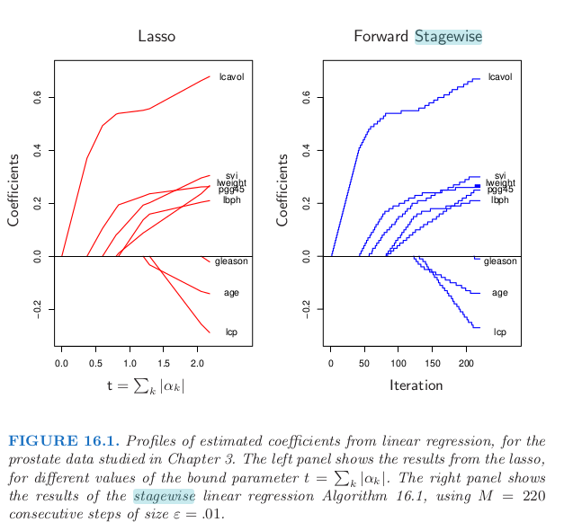

## BART

- Chipman, George, and McCulloch (2010)
- again a sum of trees
- smart, data-informed (“empirical Bayesian”) priors
- fitting procedure is MCMC
- defaults are good, don’t need much tuning

Chipman, Hugh A., Edward I. George, and Robert E. McCulloch. 2010. “BART: Bayesian Additive Regression Trees.” *The Annals of Applied Statistics* 4 (1). https://doi.org/10.1214/09-AOAS285.

## regularizing priors

- informative but non-biasing
- shrink toward ‘null value’, e.g. ridge/lasso penalties

## BART priors

- tree depth, splitting point, overall residual variance
- componentwise/independent priors on each model
- tree depth: $\alpha (1 + d)^{-\beta}$
  - $\alpha = 0.95$, $\beta = 2$: modal $d=2$, most $d \le 5$
- splitting priors: uniform over split points (observed values) and parameters
- split point/mean: scaled Normal prior
  - overall mean prediction is sum of means across $m$ trees
  - $m\mu_\mu \pm k\sqrt{m}\sigma_\mu = y_{\textrm{min}}$
  - e.g. $k=2$ for $\approx$ 95% range in (ymin, ymax)
- residual variance: inverse-chi-squared with scale matching $\sigma$
  - $\hat \sigma$ is marginal std dev *or* linear regression std dev
  - choose df (3-10) so that upper $q$ quantile is at $\hat \sigma$
- overfitting is unlikely, so choose $m$ “big enough” ($m=200$)

## MCMC rules

- **Gibbs sampling**
- draw $\sigma$ from inverse gamma (conjugate prior)
- $T_j$: grow a terminal node (0.25), prune (0.25), change a nonterminal rule (0.4), swap a rule between parent and child (0.1)
- resample $M_j$ values from a normal (and recompute residuals)
- initialize with $m$ stumps

## MCMC stuff

- burn-in (typically 200 steps)
- sampling
- single chain (typically 1000 steps)